# Analysing Business Establishments and Industry Distribution in Melbourne from 2002 to 2022.

Alicia Zhao

22 February, 2025

```r
library(readxl)

url <- "https://data.melbourne.vic.gov.au/api/explore/v2.1/catalog/datasets/business-establishments-per-block-by-anzsic/exports/xlsx?lang=en&timezone=Australia%2FSydney&use_labels=true"
destfile <- "business-establishments-per-block-by-anzsic.xlsx"
download.file(url, destfile, mode = "wb")

anzsic <- read_excel(destfile)

head(anzsic)
```

```
## # A tibble: 6 × 23
##   `Census year` `Block ID` `CLUE small area` `Accommodation and Food Services`
##   <chr>              <dbl> <chr>                                         <dbl>
## 1 2023                   5 Melbourne (CBD)                                   0
## 2 2023                  11 Melbourne (CBD)                                  23
## 3 2023                  16 Melbourne (CBD)                                  18
## 4 2023                  21 Melbourne (CBD)                                  18
## 5 2023                  25 Melbourne (CBD)                                  23
## 6 2023                  34 Melbourne (CBD)                                  32
## # ℹ 19 more variables: `Administrative and Support Services` <dbl>,
## #   `Agriculture, Forestry and Fishing` <dbl>,
## #   `Arts and Recreation Services` <dbl>, Construction <dbl>,
## #   `Education and Training` <dbl>,
## #   `Electricity, Gas, Water and Waste Services` <dbl>,
## #   `Financial and Insurance Services` <dbl>,
## #   `Health Care and Social Assistance` <dbl>, …
```

If the link doesn’t work, that’s another link to download xlsx file manually. https://data.melbourne.vic.gov.au/explore/dataset/business-establishments-per-block-by-anzsic/export/

First need to check whether there are missing values by column.

```r
colSums(is.na(anzsic))
```

```
##                                     Census year
##                                               0
##                                        Block ID
##                                               0
##                                 CLUE small area
##                                               0
##                 Accommodation and Food Services
##                                               0
##             Administrative and Support Services
##                                               0
##               Agriculture, Forestry and Fishing
##                                               0
##                    Arts and Recreation Services
##                                               0
##                                    Construction
##                                               0
##                          Education and Training
##                                               0
##      Electricity, Gas, Water and Waste Services
##                                               0
##                Financial and Insurance Services
##                                               0
##               Health Care and Social Assistance
##                                               0
##        Information Media and Telecommunications
##                                               0
##                                   Manufacturing
##                                               0
##                                          Mining
##                                               0
##                                  Other Services
##                                               0
## Professional, Scientific and Technical Services
##                                               0
##                Public Administration and Safety
##                                               0
##         Rental, Hiring and Real Estate Services
##                                               0
##                                    Retail Trade
##                                               0
##               Transport, Postal and Warehousing
##                                               0
##                                 Wholesale Trade
##                                               0
##                   Total establishments in block
##                                               0
```

The result indicates that no missing value is in this dataset.

```r
unique(anzsic$`CLUE small area`)
```

```
##  [1] "Melbourne (CBD)"              "Carlton"
##  [3] "Parkville"                    "North Melbourne"
##  [5] "West Melbourne (Residential)" "West Melbourne (Industrial)"
##  [7] "Kensington"                   "East Melbourne"
##  [9] "Melbourne (Remainder)"        "Southbank"
## [11] "Docklands"                    "Port Melbourne"
## [13] "South Yarra"                  "City of Melbourne (total)"
```

‘City of Melbourne (total)’ isn’t part of the ANZSIC area, so we need to check it out.

```r
library(tidyverse)
total_anz <- anzsic %>% filter(`CLUE small area` == "City of Melbourne (total)")
total_anz
```

```
## # A tibble: 22 × 23
##    `Census year` `Block ID` `CLUE small area`         Accommodation and Food S…¹
##    <chr>              <dbl> <chr>                                          <dbl>
##  1 2021                   0 City of Melbourne (total)                       2975
##  2 2016                   0 City of Melbourne (total)                       3005
##  3 2015                   0 City of Melbourne (total)                       2878
##  4 2014                   0 City of Melbourne (total)                       2814
##  5 2010                   0 City of Melbourne (total)                       2401
##  6 2009                   0 City of Melbourne (total)                       2329
##  7 2007                   0 City of Melbourne (total)                       2110
##  8 2004                   0 City of Melbourne (total)                       1763
##  9 2003                   0 City of Melbourne (total)                       1630
## 10 2022                   0 City of Melbourne (total)                       2830
## # ℹ 12 more rows
## # ℹ abbreviated name: ¹`Accommodation and Food Services`
## # ℹ 19 more variables: `Administrative and Support Services` <dbl>,
## #   `Agriculture, Forestry and Fishing` <dbl>,
## #   `Arts and Recreation Services` <dbl>, Construction <dbl>,
## #   `Education and Training` <dbl>,
## #   `Electricity, Gas, Water and Waste Services` <dbl>, …
```

```r
anzsic <- anzsic %>%
  filter(`CLUE small area` != "City of Melbourne (total)")
```

Block ID is not very useful for our analysis, as it is divided into small city blocks by area, and the corresponding geographical location is confidential information. We can remove this column and calculate the total number of locations of establishment in different years and areas.

```r
anzsic_group_by <- anzsic %>%
  select(-`Block ID`) %>%
  group_by(`Census year`, `CLUE small area`) %>%
  summarise(across(where(is.numeric), sum), .groups = "drop") %>%
  rename(`Total establishments in area` = `Total establishments in block`)

head(anzsic_group_by)
```

```
## # A tibble: 6 × 22
##   `Census year` `CLUE small area`  Accommodation and Fo…¹ Administrative and S…²
##   <chr>         <chr>                               <dbl>                  <dbl>
## 1 2002          Carlton                               190                     40
## 2 2002          Docklands                              23                      6
## 3 2002          East Melbourne                         54                     22
## 4 2002          Kensington                             12                      1
## 5 2002          Melbourne (CBD)                       993                    489
## 6 2002          Melbourne (Remain…                     24                     24
## # ℹ abbreviated names: ¹`Accommodation and Food Services`,
## #   ²`Administrative and Support Services`
## # ℹ 18 more variables: `Agriculture, Forestry and Fishing` <dbl>,
## #   `Arts and Recreation Services` <dbl>, Construction <dbl>,
## #   `Education and Training` <dbl>,
## #   `Electricity, Gas, Water and Waste Services` <dbl>,
## #   `Financial and Insurance Services` <dbl>, …
```

Melbourne (CBD) area has a great number of establishment locations in all fields, therefore, distinguish between CBD and Non-CBD, and calculate the total number of establishment locations in different area types.

```r
anzsic_cbd <- anzsic_group_by %>%
  mutate(Area_Type = ifelse(`CLUE small area` == "Melbourne (CBD)", "CBD", "Non-CBD"))

anzsic_cbd <- anzsic_cbd %>%
  group_by(`Census year`, Area_Type) %>%
  summarise(`Total establishments in area` = sum(`Total establishments in area`), .groups = "drop")
```

Make the plot

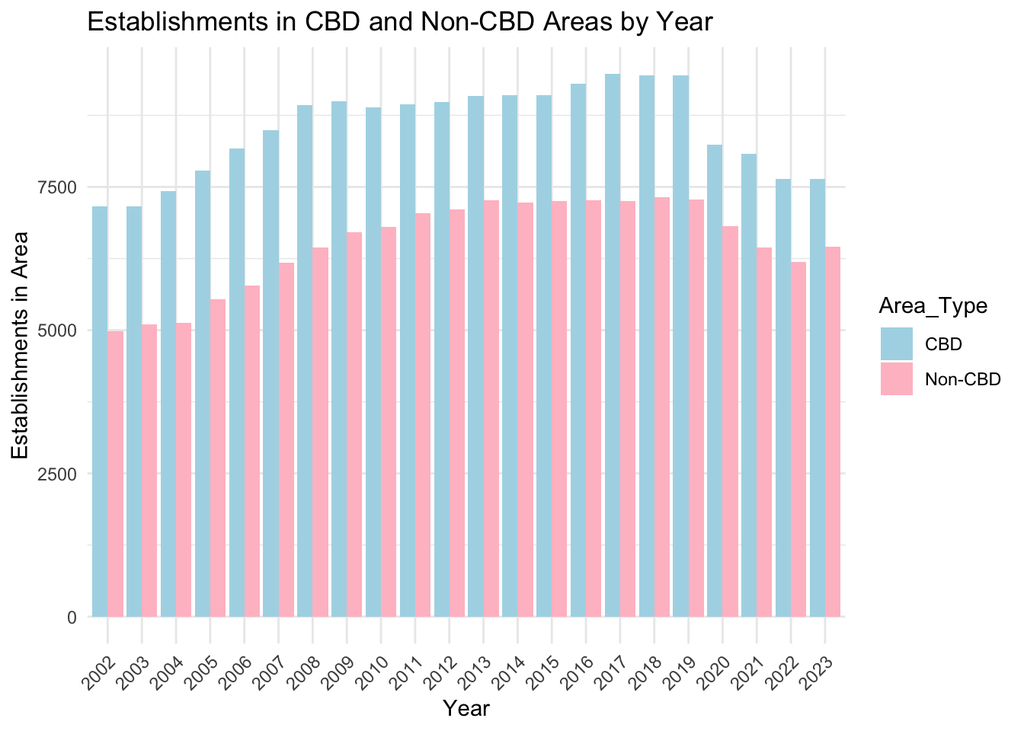

```r
library(ggplot2)

ggplot(anzsic_cbd, aes(x = `Census year`, y = `Total establishments in area`, fill = Area_Type)) +
  geom_bar(stat = "identity", position = "dodge") +
  labs(title = "Establishments in CBD and Non-CBD Areas by Year",
       x = "Year",
       y = "Establishments in Area") +
  scale_fill_manual(values = c("CBD" = "lightblue", "Non-CBD" = "pink")) +
  theme_minimal() +
  theme(axis.text.x = element_text(angle = 45, hjust = 1))
```

The number of establishment locations in the CBD is always greater than that in non-CBD areas, indicating that there are more business and employment opportunities in the CBD area. From the trend point of view, the number of establishments has been steadily increasing year by year. After 2019, due to Covid-19, the number of establishments began to decrease, especially in the CBD area.

```r
colnames(anzsic_group_by)
```

```
##  [1] "Census year"
##  [2] "CLUE small area"
##  [3] "Accommodation and Food Services"
##  [4] "Administrative and Support Services"
##  [5] "Agriculture, Forestry and Fishing"
##  [6] "Arts and Recreation Services"
##  [7] "Construction"
##  [8] "Education and Training"
##  [9] "Electricity, Gas, Water and Waste Services"
## [10] "Financial and Insurance Services"
## [11] "Health Care and Social Assistance"
## [12] "Information Media and Telecommunications"
## [13] "Manufacturing"
## [14] "Mining"
## [15] "Other Services"
## [16] "Professional, Scientific and Technical Services"
## [17] "Public Administration and Safety"
## [18] "Rental, Hiring and Real Estate Services"
## [19] "Retail Trade"
## [20] "Transport, Postal and Warehousing"
## [21] "Wholesale Trade"
## [22] "Total establishments in area"
```

Now divide different industries into five main categories, recording their indices.

Industrial: Agriculture, Forestry and Fishing Construction Electricity, Gas, Water and Waste Services Manufacturing Transport, Postal and Warehousing  
Wholesale Trade Mining

Entertainment: Arts and Recreation Services Accommodation and Food Services

Retail: Retail Trade

Institutional: Education and Training Health Care and Social Assistance

Commercial: Administrative and Support Services Financial and Insurance Services Information Media and Telecommunications  
Other Services Rental, Hiring and Real Estate Services Public Administration and Safety Professional, Scientific and Technical Services

```r
# Industrial columns by index
industrial_indices <- c(5, 7, 9, 13, 14, 20, 21)
# Entertainment columns by index
entertainment_indices <- c(3, 6)
# Retail columns by index
retail_indices <- 19
# Institutional columns by index
institutional_indices <- c(8, 11)
# Commercial columns by index
commercial_indices <- c(4, 10, 12, 15, 16, 17, 18)

anzsic_category <- anzsic_group_by %>%
  # Group the data by row
  rowwise() %>%
  mutate(
    Industrial = sum(c_across(all_of(industrial_indices))),
    Entertainment = sum(c_across(all_of(entertainment_indices))),
    Retail = sum(c_across(all_of(retail_indices))),
    Institutional = sum(c_across(all_of(institutional_indices))),
    Commercial = sum(c_across(all_of(commercial_indices)))
  ) %>%
  # Select relevant columns to create the final table
  select(`Census year`, `CLUE small area`, Industrial, Entertainment, Retail, Institutional, Commercial)

head(anzsic_category)
```

```
## # A tibble: 6 × 7
## # Rowwise:
##   `Census year` `CLUE small area`  Industrial Entertainment Retail Institutional
##   <chr>         <chr>                   <dbl>         <dbl>  <dbl>         <dbl>
## 1 2002          Carlton                    91           221    166           163
## 2 2002          Docklands                  56            32     11             4
## 3 2002          East Melbourne             33            96     16           165
## 4 2002          Kensington                 56            72      7            11
## 5 2002          Melbourne (CBD)           705          1085   1317           475
## 6 2002          Melbourne (Remain…         35            60     17            62
## # ℹ 1 more variable: Commercial <dbl>
```

The result indicates the number of establishment locations by categories. Then choose year 2002, 2012 and 2022, draw 3 pie charts to compare the differences.

```r
anzsic_filtered <- anzsic_category %>%
  filter(`Census year` %in% c(2002, 2012, 2022)) %>%
  pivot_longer(cols = Industrial:Commercial, names_to = "Category", values_to = "Total_count") %>%
  # Summarize data by Year and Category, and calculate percentages
  group_by(`Census year`, Category) %>%
  summarise(Total_count = sum(Total_count), .groups = "drop") %>%
  group_by(`Census year`) %>%
  mutate(Percentage = (Total_count / sum(Total_count)) * 100)
```

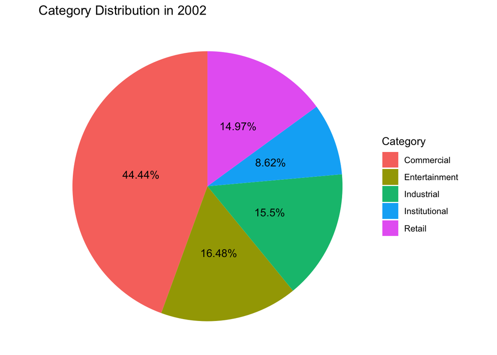

```r
# Create Pie Charts for 2002, 2012, and 2022
# Pie chart for 2002
anzsic_2002 <- ggplot(anzsic_filtered %>% filter(`Census year` == 2002), aes(x = "", y = Percentage, fill = Category)) +
  geom_bar(stat = "identity", width = 1) +
  coord_polar("y", start = 0) +
  labs(title = "Category Distribution in 2002", x = NULL, y = NULL) +
  geom_text(aes(label = paste0(round(Percentage, 2), "%")),
            position = position_stack(vjust = 0.5)) +
  theme_void() +
  theme(legend.position = "right")

# Pie chart for 2012
anzsic_2012 <- ggplot(anzsic_filtered %>% filter(`Census year` == 2012), aes(x = "", y = Percentage, fill = Category)) +
  geom_bar(stat = "identity", width = 1) +
  coord_polar("y", start = 0) +
  labs(title = "Category Distribution in 2012", x = NULL, y = NULL) +
  geom_text(aes(label = paste0(round(Percentage, 2), "%")),
            position = position_stack(vjust = 0.5)) +
  theme_void() +
  theme(legend.position = "right")

# Pie chart for 2022
anzsic_2022 <- ggplot(anzsic_filtered %>% filter(`Census year` == 2022), aes(x = "", y = Percentage, fill = Category)) +
  geom_bar(stat = "identity", width = 1) +
  coord_polar("y", start = 0) +
  labs(title = "Category Distribution in 2022", x = NULL, y = NULL) +
  geom_text(aes(label = paste0(round(Percentage, 2), "%")),
            position = position_stack(vjust = 0.5)) +
  theme_void() +
  theme(legend.position = "right")

# Display the pie charts
anzsic_2002
```

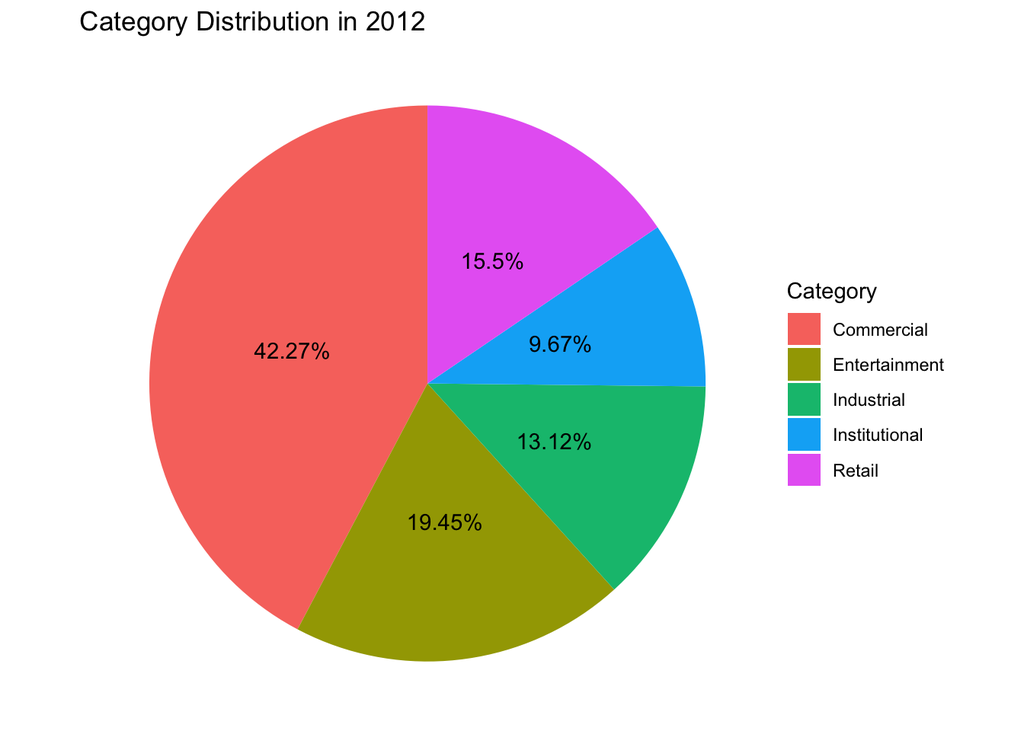

```r
anzsic_2012
```

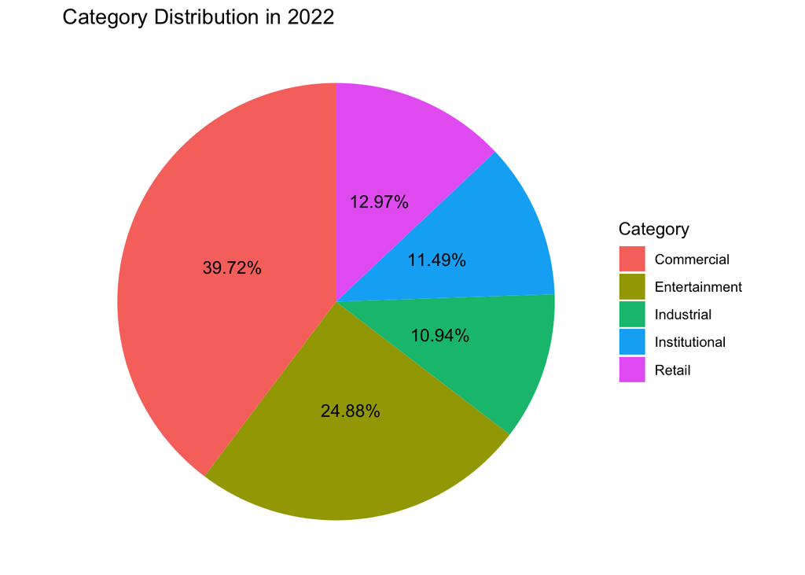

```r
anzsic_2022
```

Now consider about areas’ trends, choose year 2002, 2006, 2010, 2014, 2018 and 2022 to do the research.

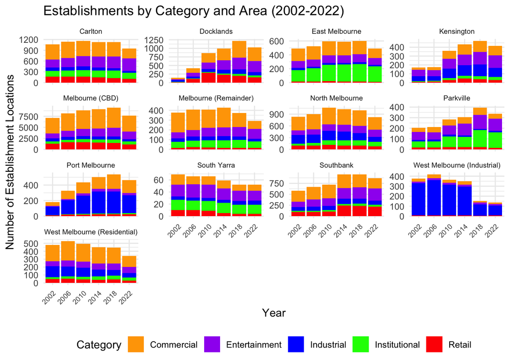

```r
anzsic_area <- anzsic_category %>%
  filter(`Census year` %in% c(2002, 2006, 2010, 2014, 2018, 2022)) %>%
  pivot_longer(cols = Industrial:Commercial, names_to = "Category", values_to = "Establishments")

# Create a faceted bar plot to show categories over time for each area
ggplot(anzsic_area, aes(x = `Census year`, y = Establishments, fill = Category)) +
  geom_bar(stat = "identity") +
  facet_wrap(~`CLUE small area`, nrow = 4, scales = "free_y") +
  labs(title = "Establishments by Category and Area (2002-2022)",
       x = "Year",
       y = "Number of Establishment Locations",
       fill = "Category") +
  theme_minimal() +
  scale_fill_manual(values = c("orange", "purple", "blue", "green", "red")) +
  theme(axis.text.x = element_text(angle = 45, hjust = 1, size = 7)) +
  theme(legend.position = "bottom") +
  theme(strip.text = element_text(size = 7))
```

Then only focus on the year 2022 as the most recent data we can get. Create a stacked bar plot for all areas with catogories of 2022.

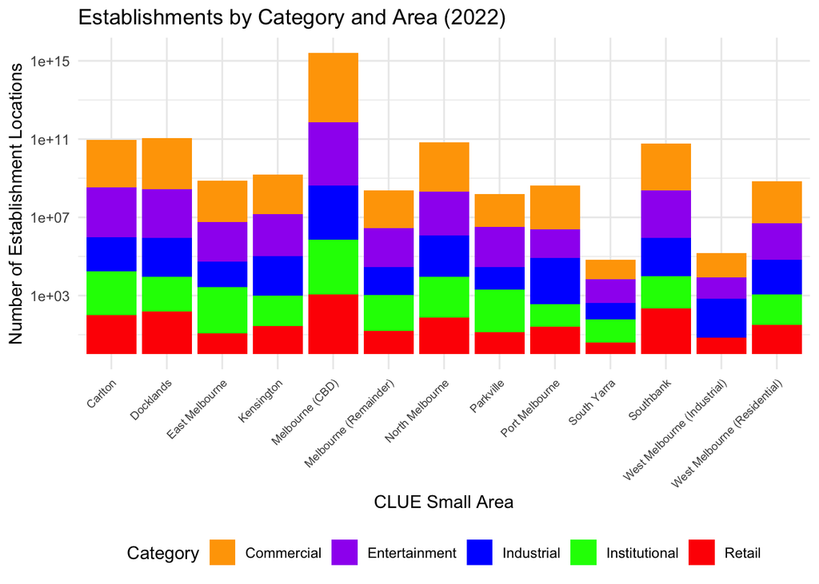

```r
anzsic_category %>%
  filter(`Census year` == 2022) %>%
  pivot_longer(cols = Industrial:Commercial, names_to = "Category", values_to = "Establishments") %>%
  filter(Establishments > 0) %>%
  ggplot(aes(x = `CLUE small area`, y = Establishments, fill = Category)) +
  geom_bar(stat = "identity", position = "stack") +
  labs(title = "Establishments by Category and Area (2022)",
       x = "CLUE Small Area",
       y = "Number of Establishment Locations",
       fill = "Category") +
  theme_minimal() +
  scale_fill_manual(values = c("orange", "purple", "blue", "green", "red")) +
  theme(axis.text.x = element_text(angle = 45, hjust = 1, size = 7)) +
  theme(legend.position = "bottom") +
  scale_y_log10() # Apply log10 scaling, reduce the differences between data
```

In most areas, Commercial and Entertainment establishments are the dominant categories, particularly in high-density areas like the Melbourne CBD and Docklands.

Areas like Kensington, North Melbourne, and Parkville show more balanced distributions across categories.

I wonder which areas have similar patterns, so cluster analysis is very important. Before we start, scale the data to reduce the impact of the much larger values in the CBD.

```r
anzsic_2022 <- anzsic_category %>%
  filter(`Census year` == 2022) %>%
  select(-`Census year`)

scaled_anzsic_2022 <- anzsic_2022 %>%
  select(-`CLUE small area`)

scaled_anzsic_2022 <- scale(scaled_anzsic_2022)
scaled_anzsic_2022
```

```
##        Industrial Entertainment      Retail Institutional  Commercial
##  [1,] -0.39452260    0.16808043 -0.12320825    0.28379148 -0.15612644
##  [2,] -0.12878199    0.13504042  0.03696247   -0.35484901 -0.02999633
##  [3,] -0.63368915   -0.36276229 -0.42019146    0.56319669 -0.30222716
##  [4,] -0.08227738   -0.26804761 -0.36680122   -0.49740269 -0.33165751
##  [5,]  3.05346183    3.22758471  3.25038760    3.07214145  3.30299191
##  [6,] -0.58718454   -0.36496496 -0.40684390   -0.32633827 -0.35583245
##  [7,]  0.09045402   -0.18654894 -0.20329361   -0.03552876 -0.10882765
##  [8,] -0.68019376   -0.33192495 -0.41351768    0.14123780 -0.39367149
##  [9,]  0.74816203   -0.51915164 -0.37681189   -0.61144563 -0.27174571
## [10,] -0.72669836   -0.54778631 -0.44688658   -0.61144563 -0.43361269
## [11,] -0.16199956    0.02490708  0.26387100   -0.44608336 -0.19606764
## [12,] -0.10220793   -0.55659698 -0.43687591   -0.69697784 -0.42625510
## [13,] -0.39452260   -0.41782896 -0.35679055   -0.48029624 -0.29697173
## attr(,"scaled:center")
##    Industrial Entertainment        Retail Institutional    Commercial
##      116.3846      264.6923      137.9231      122.2308      422.5385
## attr(,"scaled:scale")
##    Industrial Entertainment        Retail Institutional    Commercial
##      150.5227      453.9951      299.6802      175.3725      951.3985
```

However, CBD still have much larger values than others, log tranformation has used to reduce values.

```r
scaled_2022_log <- log1p(scaled_anzsic_2022)
scaled_2022_log
```

```
##        Industrial Entertainment      Retail Institutional  Commercial
##  [1,] -0.50173804    0.15536174 -0.13148577    0.24981779 -0.16975261
##  [2,] -0.13786303    0.12666827  0.03629574   -0.43827089 -0.03045542
##  [3,] -1.00427299   -0.45061252 -0.54505734    0.44673289 -0.35986167
##  [4,] -0.08586009   -0.31203981 -0.45697088   -0.68796600 -0.40295453
##  [5,]  1.39957129    1.44163084  1.44701018    1.40416902  1.45931057
##  [6,] -0.88475462   -0.45407510 -0.52229768   -0.39502718 -0.43979642
##  [7,]  0.08659414   -0.20646951 -0.22726906   -0.03617527 -0.11521743
##  [8,] -1.14003995   -0.40335477 -0.53361276    0.13211346 -0.50033334
##  [9,]  0.55856497   -0.73220332 -0.47290687   -0.94532217 -0.31710499
## [10,] -1.29717919   -0.79360044 -0.59219221   -0.94532217 -0.56847714
## [11,] -0.17673666    0.02460195  0.23417923   -0.59074107 -0.21824015
## [12,] -0.10781678   -0.81327616 -0.57425527   -1.19394933 -0.55557041
## [13,] -0.50173804   -0.54099100 -0.44128487   -0.65449633 -0.35235818
## attr(,"scaled:center")
##    Industrial Entertainment        Retail Institutional    Commercial
##      116.3846      264.6923      137.9231      122.2308      422.5385
## attr(,"scaled:scale")
##    Industrial Entertainment        Retail Institutional    Commercial
##      150.5227      453.9951      299.6802      175.3725      951.3985
```

Define number of clusters, using 2 methods.

Method 1: Silhouette score

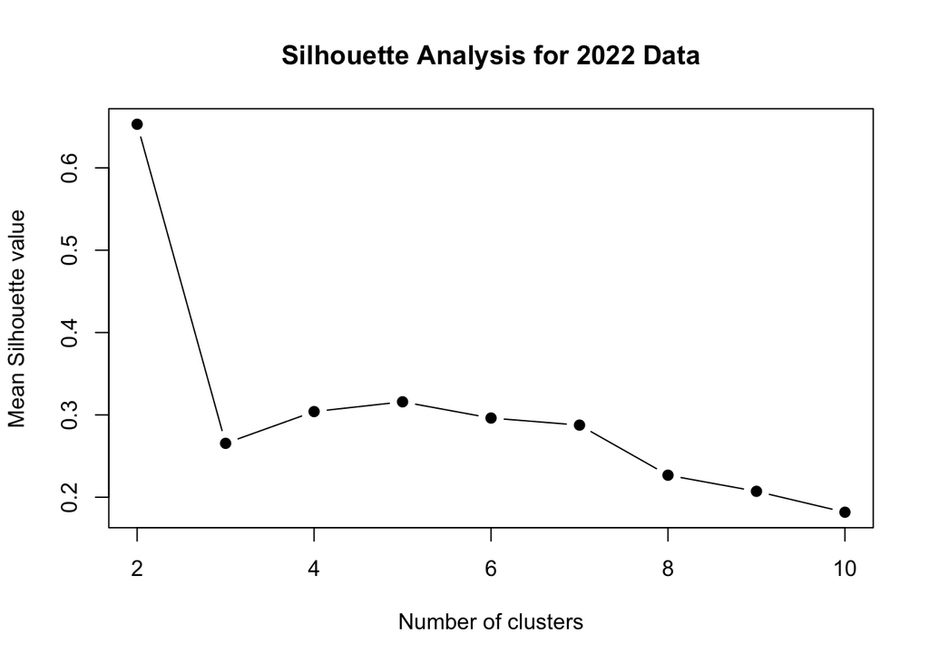

```r
library(cluster)

silhouette_vals <- c()

for (i in 2:10) {
  kmeans_result <- kmeans(scaled_2022_log, centers = i, iter.max = 10, nstart = 10)
  silhouette_val <- silhouette(kmeans_result$cluster, dist(scaled_2022_log))
  silhouette_vals <- c(silhouette_vals, mean(silhouette_val[, 3]))  # Mean silhouette value for each cluster
}

plot(2:10, silhouette_vals, type = "b", pch = 19, xlab = "Number of clusters",
     ylab = "Mean Silhouette value", main = "Silhouette Analysis for 2022 Data")
```

Method 2: Elbow method

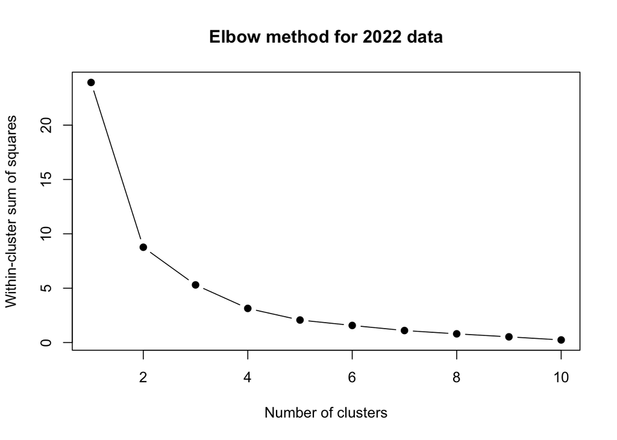

```r
wss <- c()
for (i in 1:10) {
  kmeans_result <- kmeans(scaled_2022_log, centers = i, iter.max = 10, nstart = 10)
  wss[i] <- kmeans_result$tot.withinss
}

plot(1:10, wss, type = "b", pch = 19, xlab = "Number of clusters",
     ylab = "Within-cluster sum of squares", main = "Elbow method for 2022 data")
```

The graph highlights 2 clusters are the best choice.

However, Melbourne (CBD) has larger values and will always be splited as one cluster, so I choose 3 clusters for analyzing.

Method 1: Hierarchical clusters

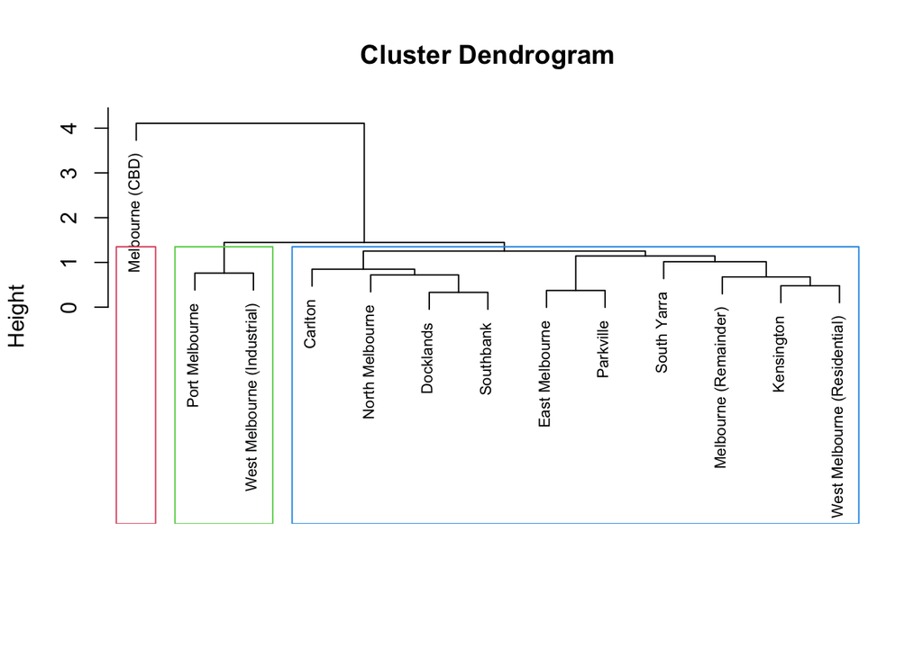

```r
clusters <- hclust(dist(scaled_2022_log), method = 'average')
plot(clusters, labels = anzsic_2022$`CLUE small area`, cex = 0.7, xlab = "", sub = "")
rect.hclust(clusters, k = 3, border = 2:4)
```

Use Industrial and Institutional variables as examples to analyze differences between clusters

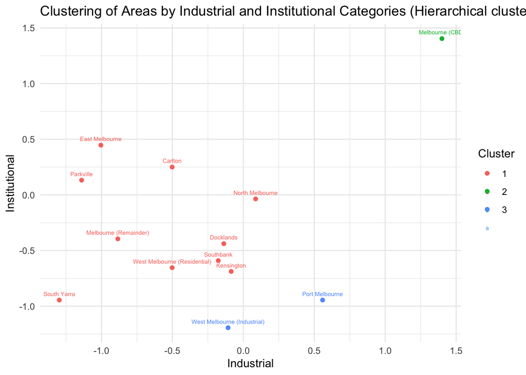

```r
clusterCut <- cutree(clusters, k = 3)

ggplot(as.data.frame(scaled_2022_log), aes(x = Industrial, y = Institutional, color = as.factor(clusterCut))) +
  geom_point() +
  geom_text(aes(label = anzsic_2022$`CLUE small area`), vjust = -1, size = 2) +
  labs(title = "Clustering of Areas by Industrial and Institutional Categories (Hierarchical clusters)",
       x = "Industrial", y = "Institutional", color = "Cluster") +
  theme_minimal()
```

Cluster 2: Melbourne (CBD) Cluster 3: West Melbourne (Industrial), Port Melbourne Cluster 1: Other areas

- Most of Cluster 1 have a more balanced or moderate level of institutional and industrial establishments, without one dominating over the other.
- Cluster 2 forms its own distinct cluster due to its high concentration of both Institutional and Industrial establishments, which sets it apart from all other areas.
- Cluster 3 is in a separate cluster due to their higher focus on industrial activity and lower institutional presence.

```r
# Calculate silhouette score
cluster_hier_numeric <- as.numeric(as.character(clusterCut))
silhouette_hierarchical <- silhouette(cluster_hier_numeric, dist(scaled_2022_log))
mean_silhouette_hierarchical <- mean(silhouette_hierarchical[, 3])

mean_silhouette_hierarchical
```

```
## [1] 0.232817
```

Method 2: k-means

```r
set.seed(1234)
cluster_k <- kmeans(scaled_2022_log, 3, iter.max = 10, nstart = 10)
# Create a data frame to save area name and cluster number
area_with_clusters <- data.frame(Area = anzsic_2022$`CLUE small area`, Cluster = as.factor(cluster_k$cluster))

area_with_clusters
```

```
##                            Area Cluster
## 1                       Carlton       2
## 2                     Docklands       1
## 3                East Melbourne       2
## 4                    Kensington       1
## 5               Melbourne (CBD)       3
## 6         Melbourne (Remainder)       2
## 7               North Melbourne       1
## 8                     Parkville       2
## 9                Port Melbourne       1
## 10                  South Yarra       2
## 11                    Southbank       1
## 12  West Melbourne (Industrial)       1
## 13 West Melbourne (Residential)       1
```

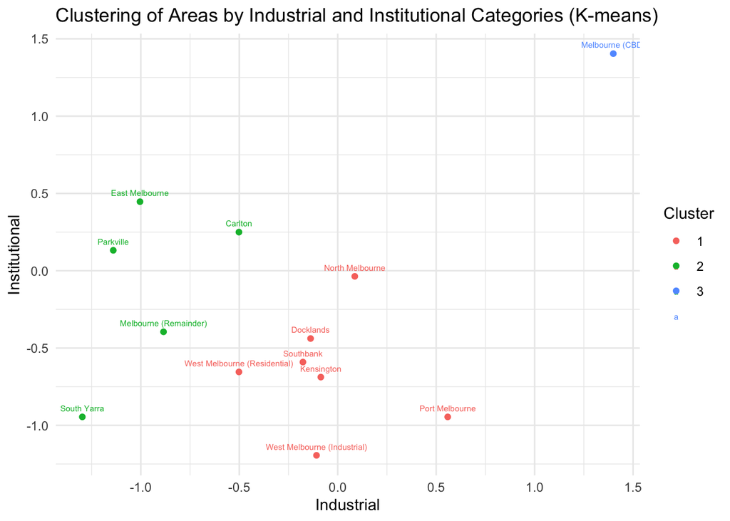

```r
cluster_k$cluster <- as.factor(cluster_k$cluster)

ggplot(as.data.frame(scaled_2022_log), aes(x = Industrial, y = Institutional, color = cluster_k$cluster)) +
  geom_point() +
  geom_text(aes(label = anzsic_2022$`CLUE small area`), vjust = -1, size = 2) +
  ggtitle("Clustering of Areas by Industrial and Institutional Categories (K-means)") +
  labs(color = "Cluster") +
  theme_minimal()
```

* The majority of areas in Cluster 1 have relatively lower industrial and institutional activities * Carlton, Parkville, East Melbourne, and similar areas form a group of institutional-heavy areas. * The Melbourne CBD is distinct, having significantly more industrial and institutional establishments compared to other areas

```r
# Calculate silhouette score
cluster_kmeans_numeric <- as.numeric(as.character(cluster_k$cluster))
silhouette_kmeans <- silhouette(cluster_kmeans_numeric, dist(scaled_2022_log))
mean_silhouette_kmeans <- mean(silhouette_kmeans[, 3])

mean_silhouette_kmeans
```

```
## [1] 0.2654368
```

K-means is a better method in this case. Will use k-means to get similar patterns for other variables

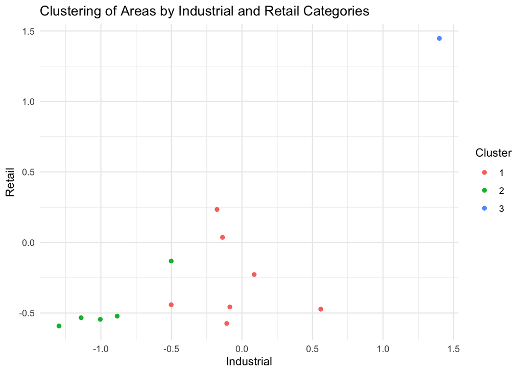

```r
ggplot(as.data.frame(scaled_2022_log), aes(x = Industrial, y = Retail, color = cluster_k$cluster)) +
  geom_point() +
  ggtitle("Clustering of Areas by Industrial and Retail Categories") +
  labs(color = "Cluster") +
  theme_minimal()
```

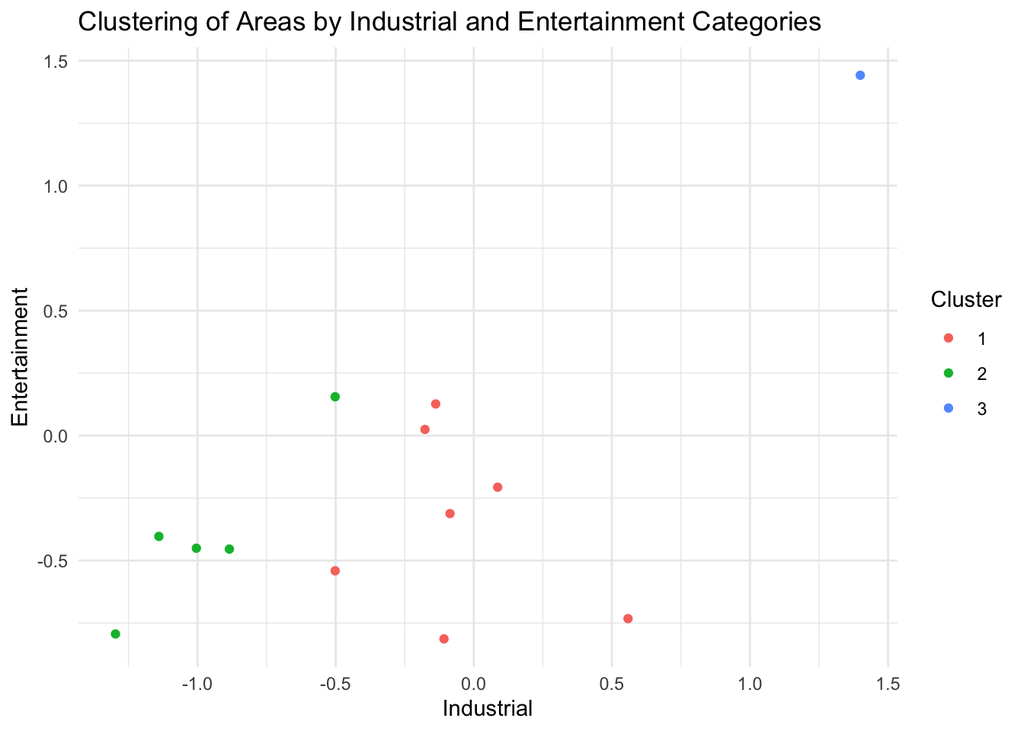

```r
ggplot(as.data.frame(scaled_2022_log), aes(x = Industrial, y = Entertainment, color = cluster_k$cluster)) +
  geom_point() +
  ggtitle("Clustering of Areas by Industrial and Entertainment Categories") +
  labs(color = "Cluster") +
  theme_minimal()
```

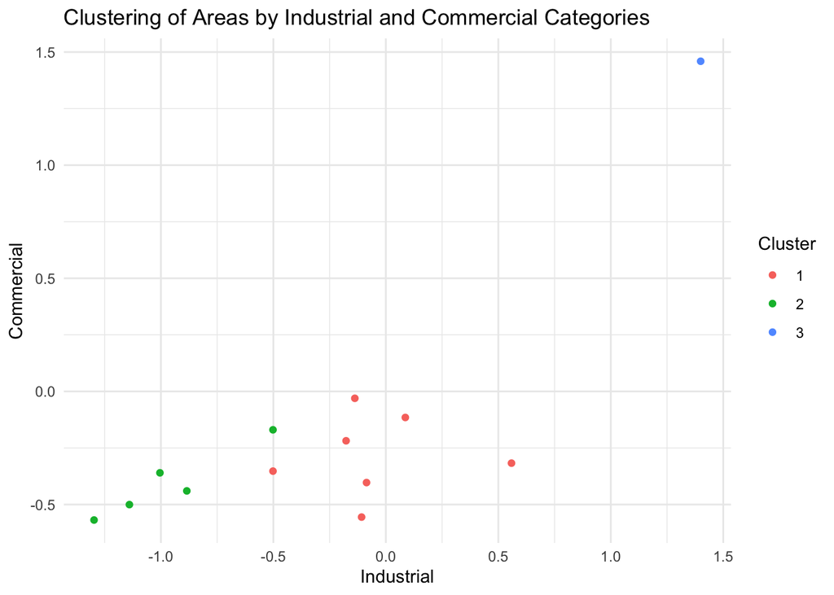

```r
ggplot(as.data.frame(scaled_2022_log), aes(x = Industrial, y = Commercial, color = cluster_k$cluster)) +
  geom_point() +
  ggtitle("Clustering of Areas by Industrial and Commercial Categories") +
  labs(color = "Cluster") +
  theme_minimal()
```

Make predictions for the future 5 years.

```r
total_anz <- total_anz %>%
  select(-`Block ID`)

head(total_anz)
```

```
## # A tibble: 6 × 22
##   `Census year` `CLUE small area`  Accommodation and Fo…¹ Administrative and S…²
##   <chr>         <chr>                               <dbl>                  <dbl>
## 1 2021          City of Melbourne…                   2975                    460
## 2 2016          City of Melbourne…                   3005                    646
## 3 2015          City of Melbourne…                   2878                    647
## 4 2014          City of Melbourne…                   2814                    668
## 5 2010          City of Melbourne…                   2401                    731
## 6 2009          City of Melbourne…                   2329                    756
## # ℹ abbreviated names: ¹`Accommodation and Food Services`,
## #   ²`Administrative and Support Services`
## # ℹ 18 more variables: `Agriculture, Forestry and Fishing` <dbl>,
## #   `Arts and Recreation Services` <dbl>, Construction <dbl>,
## #   `Education and Training` <dbl>,
## #   `Electricity, Gas, Water and Waste Services` <dbl>,
## #   `Financial and Insurance Services` <dbl>, …
```

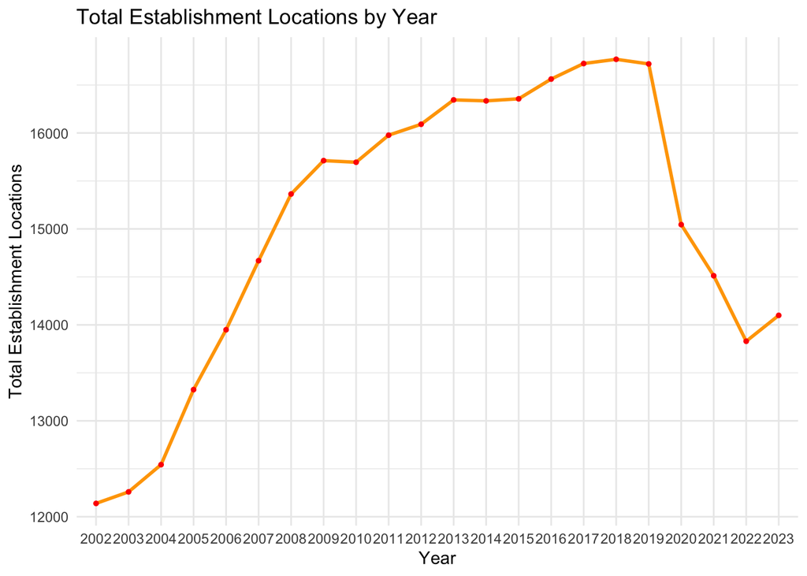

```r
ggplot(data = total_anz, aes(x = `Census year`, y = `Total establishments in block`, group = 1)) +
  geom_line(color = "orange", size = 1) +
  geom_point(color = "red", size = 1) +
  labs(title = "Total Establishment Locations by Year",
       x = "Year",
       y = "Total Establishment Locations") +
  theme_minimal()
```

The number of establishment locations grew steadily from 2002 to 2019 but experienced a sharp decline starting in 2020, likely due to the impact of the COVID-19 pandemic.

```r
library(tseries)
library(forecast)
```

First sort the data by year and create a time series starts from 2002. Using 3 methods to predict the trend for next 5 years.

```r
total_anz <- total_anz[order(total_anz$`Census year`), ]
total_anz_ts <- ts(total_anz$`Total establishments in block`, start = c(2002), frequency = 1)
```

Method 1: Linear Regression Model.

```r
# time series is yearly, therefore, no seasonal impact
linear_anz <- tslm(total_anz_ts ~ trend)
accuracy(linear_anz)
```

```
##                        ME     RMSE      MAE        MPE     MAPE     MASE
## Training set -3.72066e-13 1272.293 1176.149 -0.7620243 8.027796 3.129641
##                   ACF1
## Training set 0.8105473
```

```r
forecast(linear_anz, h=5)
```

```
##      Point Forecast    Lo 80    Hi 80    Lo 95    Hi 95
## 2024       16424.18 14491.06 18357.31 13381.62 19466.74
## 2025       16544.00 14589.07 18498.93 13467.13 19620.87
## 2026       16663.82 14685.54 18642.09 13550.20 19777.44
## 2027       16783.64 14780.52 18786.75 13630.92 19936.35
## 2028       16903.45 14874.06 18932.85 13709.38 20097.53
```

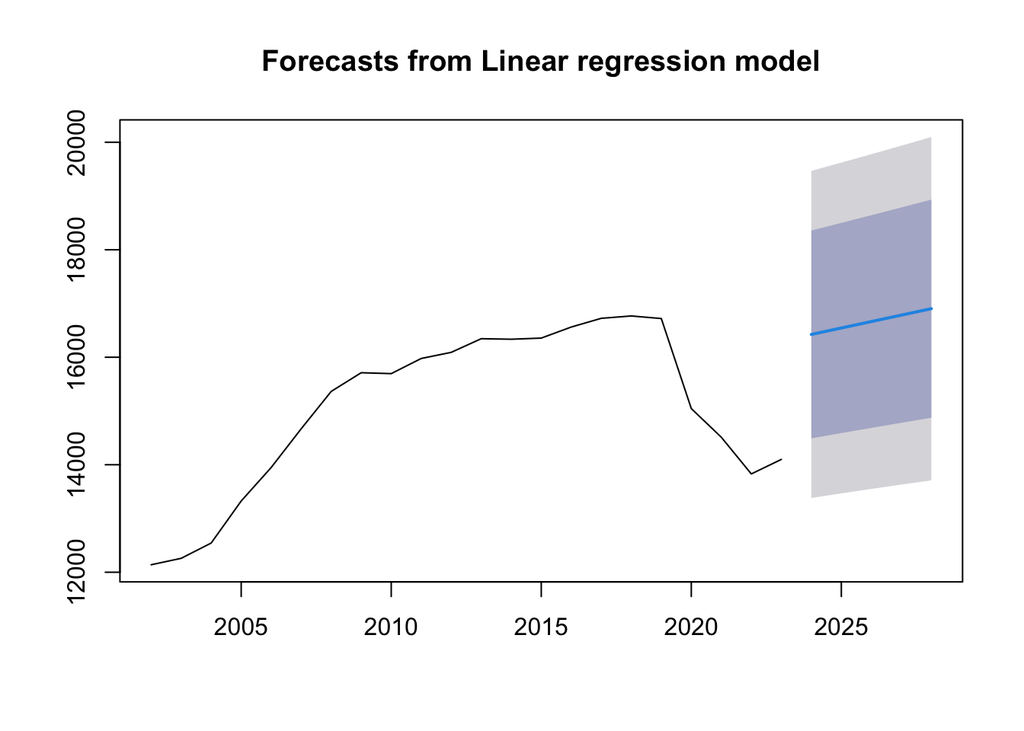

```r
plot(forecast(linear_anz, h=5))
```

The linear regression forecast shows a steady trend for the number of establishment locations over the next five years.

Method 2: ETS Model

```r
ets_anz <- ets(total_anz_ts)
accuracy(ets_anz)
```

```
##                    ME     RMSE      MAE      MPE     MAPE      MASE      ACF1
## Training set 89.88857 525.6733 359.5396 0.623651 2.460266 0.9567069 0.5120304
```

```r
forecast(ets_anz,h=5)
```

```
##      Point Forecast    Lo 80    Hi 80    Lo 95    Hi 95
## 2024       14098.97 13436.02 14761.92 13085.08 15112.87
## 2025       14098.97 13161.15 15036.80 12664.70 15533.25
## 2026       14098.97 12950.01 15247.93 12341.79 15856.16
## 2027       14098.97 12771.83 15426.11 12069.28 16128.66
## 2028       14098.97 12614.69 15583.25 11828.96 16368.99
```

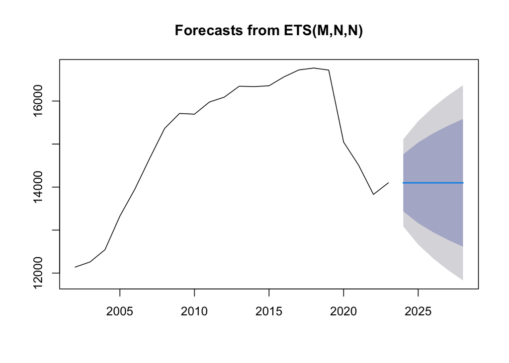

```r
plot(forecast(ets_anz, h=5))
```

Method 3: Auto.arima Model

```r
arima_anz <- auto.arima(total_anz_ts)
summary(arima_anz)
```

```
## Series: total_anz_ts
## ARIMA(0,2,1)
##
## Coefficients:
##           ma1
##       -0.5750
## s.e.   0.2815
##
## sigma^2 = 248391:  log likelihood = -152.29
## AIC=308.59   AICc=309.29   BIC=310.58
##
## Training set error measures:
##                     ME     RMSE      MAE        MPE     MAPE      MASE
## Training set -48.48194 463.1623 262.4461 -0.2448277 1.766468 0.6983486
##                    ACF1
## Training set 0.03847962
```

```r
forecast(arima_anz, h = 5)
```

```
##      Point Forecast    Lo 80    Hi 80     Lo 95    Hi 95
## 2024       13840.85 13202.14 14479.56 12864.027 14817.67
## 2025       13582.70 12470.80 14694.61 11882.188 15283.21
## 2026       13324.55 11702.05 14947.05 10843.149 15805.95
## 2027       13066.40 10888.36 15244.44  9735.380 16397.42
## 2028       12808.25 10030.17 15586.33  8559.549 17056.95
```

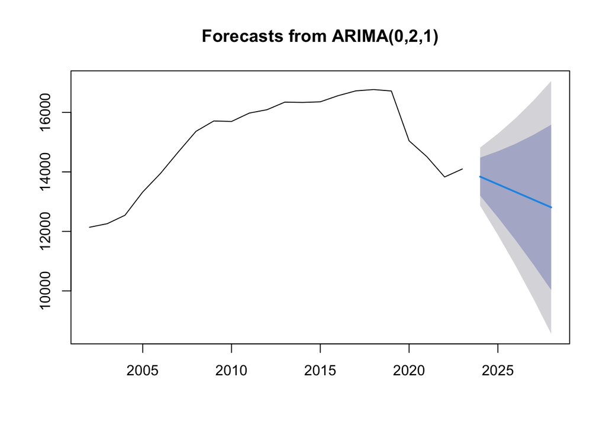

```r
plot(forecast(arima_anz, h = 5))
```

```r
# Compare 3 methods' AIC
AIC(linear_anz, ets_anz, arima_anz)
```

```
##            df      AIC
## linear_anz  3 382.9706
## ets_anz     3 349.1803
## arima_anz   2 308.5871
```

auto.arima has the smallest AIC, which means the prediction is more reliable. So we choose this prediction method for the following analysis.

In order to predict the trend of different industries, create a new data frame with 5 categories.

```r
total_cat <- setNames(data.frame(
  Year = total_anz$`Census year`,
  Industrial = rowSums(total_anz[, c(5, 7, 9, 13, 14, 20, 21)]),
  Entertainment = rowSums(total_anz[, c(3, 6)]),
  Retail = total_anz[, 19],
  Institutional = rowSums(total_anz[, c(8, 11)]),
  Commercial = rowSums(total_anz[, c(4, 10, 12, 15, 16, 17, 18)])
), c("Year", "Industrial", "Entertainment", "Retail", "Institutional", "Commercial"))
```

```r
categories <- c("Industrial", "Entertainment", "Retail", "Institutional", "Commercial")

# Create time series for each category and store them in a list
ts_list <- lapply(categories, function(cat) ts(total_cat[[cat]], start = min(total_cat$Year), frequency = 1))

# Fit ARIMA models for each time series and store the models in a list
arima_models <- lapply(ts_list, auto.arima)

# Forecast for the next 5 years for each category and store the forecasts in a list
forecasts <- lapply(arima_models, forecast, h = 5)

# Assign names to the forecasts
names(forecasts) <- categories
```

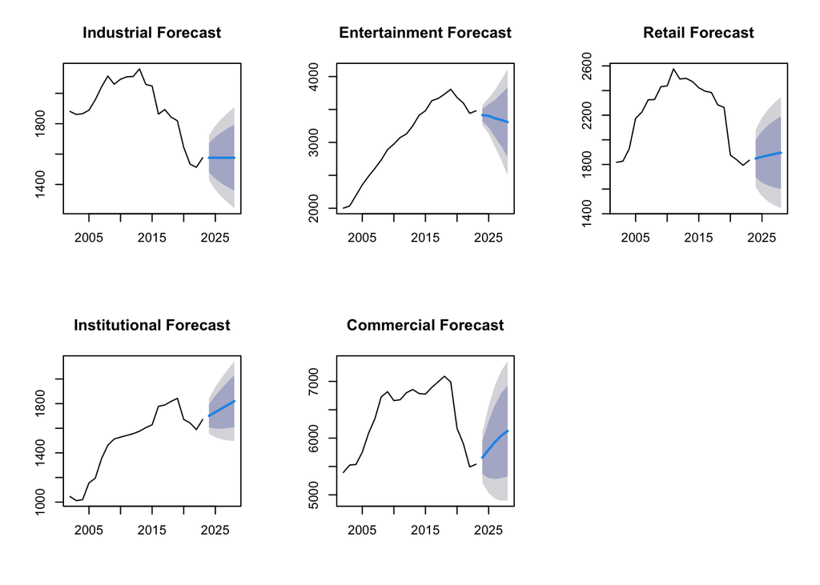

```r
# Define plot titles
titles <- c("Industrial Forecast", "Entertainment Forecast", "Retail Forecast",
            "Institutional Forecast", "Commercial Forecast")

par(mfrow = c(2, 3))

# Use a loop to plot each forecast
for (i in 1:length(forecasts)) {
  plot(forecasts[[i]], main = titles[i])
}

par(mfrow = c(1, 1))
```

Now only focus on Commercial category.

```r
forecasts$Commercial
```

```
##      Point Forecast    Lo 80    Hi 80    Lo 95    Hi 95
## 2024       5656.548 5367.474 5945.621 5214.448 6098.647
## 2025       5797.459 5296.213 6298.705 5030.870 6564.048
## 2026       5931.644 5278.224 6585.064 4932.324 6930.963
## 2027       6043.295 5294.415 6792.175 4897.981 7188.609
## 2028       6126.771 5325.501 6928.040 4901.335 7352.207
```

There are 2 columns may related to IT jobs which IT students may be interested in, called “Information Media and Telecommunications” and “Professional, Scientific and Technical Services”.

```r
# Create time series for each column
Info_media_ts <- ts(total_anz[, 12], start = min(total_anz$`Census year`), frequency = 1)
tech_serv_ts <- ts(total_anz[, 16], start = min(total_anz$`Census year`), frequency = 1)

# Fit ARIMA models to both time series
Info_media <- auto.arima(Info_media_ts)
tech_serv <- auto.arima(tech_serv_ts)

# Forecast for the next 5 years for both columns
Info_media_forecast <- forecast(Info_media, h = 5)
tech_serv_forecast <- forecast(tech_serv, h = 5)

Info_media_forecast
```

```
##      Point Forecast    Lo 80    Hi 80     Lo 95    Hi 95
## 2024       202.4317 185.7928 219.0705 176.98479 227.8785
## 2025       202.1086 171.1600 233.0573 154.77677 249.4405
## 2026       201.9251 157.7869 246.0632 134.42156 269.4286
## 2027       201.8207 145.7839 257.8575 116.11982 287.5216
## 2028       201.7614 135.0159 268.5069  99.68303 303.8398
```

```r
tech_serv_forecast
```

```
##      Point Forecast    Lo 80    Hi 80    Lo 95    Hi 95
## 2024       2214.284 2089.034 2339.535 2022.730 2405.839
## 2025       2259.108 2035.196 2483.021 1916.664 2601.553
## 2026       2302.736 2002.200 2603.273 1843.105 2762.367
## 2027       2340.698 1986.972 2694.423 1799.721 2881.675
## 2028       2370.975 1983.940 2758.009 1779.057 2962.893
```

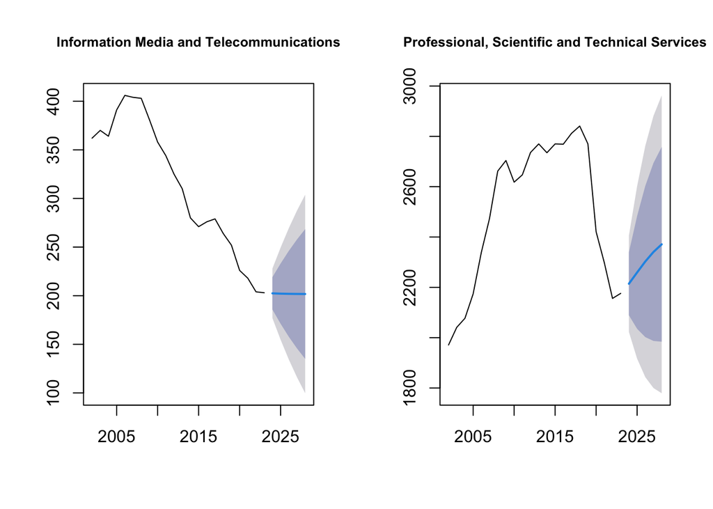

```r
# Plot the forecasts
par(mfrow = c(1, 2))
plot(Info_media_forecast, main = "Information Media and Telecommunications", cex.main = 0.8)
plot(tech_serv_forecast, main = "Professional, Scientific and Technical Services", cex.main = 0.8)
```

```r
par(mfrow = c(1, 1))
```